# airbnb_final

```python
import pandas as pd
import numpy as np
import matplotlib.pyplot as plt
import seaborn as sns
from sklearn import metrics
from sklearn.linear_model import LinearRegression
import scipy.stats as st
from scipy import stats
from sklearn.metrics import mean_squared_error
import math
```

```python
data=pd.read_csv("airbnb.csv")
df=pd.DataFrame(data)
```

```python
df.sample(5)
```

|  | id | name | host_id | host_name | neighbourhood_group | neighbourhood | latitude | longitude | room_type | price | minimum_nights | number_of_reviews | last_review | reviews_per_month | calculated_host_listings_count | availability_365 |
| --- | --- | --- | --- | --- | --- | --- | --- | --- | --- | --- | --- | --- | --- | --- | --- | --- |
| 36076 | 28666578 | Large Cozy Bedroom 10 mins from Times Sq. 33C3 | 190921808 | John | Manhattan | Hell's Kitchen | 40.75584 | -73.99559 | Private room | 120 | 7 | 4 | 2019-04-16 | 0.44 | 47 | 365 |
| 14024 | 10686406 | Master Bedroom w/ en suite | 55207670 | David | Queens | Astoria | 40.76446 | -73.92988 | Private room | 65 | 2 | 0 | NaN | NaN | 1 | 0 |
| 10709 | 8239352 | Private Room 12x12 close to manhattan | 43449898 | Ashley | Queens | Maspeth | 40.72194 | -73.91138 | Private room | 59 | 1 | 85 | 2019-06-30 | 1.85 | 1 | 176 |
| 12156 | 9433088 | Relaxing Retreat in Williamsburg | 34236533 | Stan | Brooklyn | Williamsburg | 40.70851 | -73.94244 | Private room | 130 | 5 | 102 | 2019-07-01 | 2.48 | 1 | 288 |
| 44487 | 34256176 | Nice 3Beds/2bedroom Apartment, 5min TIME SQUARE. | 41124793 | Gary | Manhattan | Hell's Kitchen | 40.76515 | -73.98586 | Entire home/apt | 389 | 1 | 1 | 2019-06-19 | 1.00 | 1 | 0 |

```python
df.index
```

```
RangeIndex(start=0, stop=48895, step=1)
```

```python
df.values
```

```
array([[2539, 'Clean & quiet apt home by the park', 2787, ..., 0.21, 6,
        365],
       [2595, 'Skylit Midtown Castle', 2845, ..., 0.38, 2, 355],
       [3647, 'THE VILLAGE OF HARLEM....NEW YORK !', 4632, ..., nan, 1,
        365],
       ...,
       [36485431, 'Sunny Studio at Historical Neighborhood', 23492952,
        ..., nan, 1, 27],
       [36485609, '43rd St. Time Square-cozy single bed', 30985759, ...,
        nan, 6, 2],
       [36487245, "Trendy duplex in the very heart of Hell's Kitchen",
        68119814, ..., nan, 1, 23]], dtype=object)
```

```python
df.dtypes
```

```
id                                  int64
name                               object
host_id                             int64
host_name                          object
neighbourhood_group                object
neighbourhood                      object
latitude                          float64
longitude                         float64
room_type                          object
price                               int64
minimum_nights                      int64
number_of_reviews                   int64
last_review                        object
reviews_per_month                 float64
calculated_host_listings_count      int64
availability_365                    int64
dtype: object
```

```python
df.columns
```

```
Index(['id', 'name', 'host_id', 'host_name', 'neighbourhood_group',
       'neighbourhood', 'latitude', 'longitude', 'room_type', 'price',
       'minimum_nights', 'number_of_reviews', 'last_review',
       'reviews_per_month', 'calculated_host_listings_count',
       'availability_365'],
      dtype='object')
```

```python
df.info()
```

```
<class 'pandas.core.frame.DataFrame'>
RangeIndex: 48895 entries, 0 to 48894
Data columns (total 16 columns):
 #   Column                          Non-Null Count  Dtype
---  ------                          --------------  -----
 0   id                              48895 non-null  int64
 1   name                            48879 non-null  object
 2   host_id                         48895 non-null  int64
 3   host_name                       48874 non-null  object
 4   neighbourhood_group             48895 non-null  object
 5   neighbourhood                   48895 non-null  object
 6   latitude                        48895 non-null  float64
 7   longitude                       48895 non-null  float64
 8   room_type                       48895 non-null  object
 9   price                           48895 non-null  int64
 10  minimum_nights                  48895 non-null  int64
 11  number_of_reviews               48895 non-null  int64
 12  last_review                     38843 non-null  object
 13  reviews_per_month               38843 non-null  float64
 14  calculated_host_listings_count  48895 non-null  int64
 15  availability_365                48895 non-null  int64
dtypes: float64(3), int64(7), object(6)
memory usage: 6.0+ MB
```

```python
df.isnull().sum()
```

```
id                                    0
name                                 16
host_id                               0
host_name                            21
neighbourhood_group                   0
neighbourhood                         0
latitude                              0
longitude                             0
room_type                             0
price                                 0
minimum_nights                        0
number_of_reviews                     0
last_review                       10052
reviews_per_month                 10052
calculated_host_listings_count        0
availability_365                      0
dtype: int64
```

```python
df.isnull().sum()
```

```
id                                    0
name                                 16
host_id                               0
host_name                            21
neighbourhood_group                   0
neighbourhood                         0
latitude                              0
longitude                             0
room_type                             0
price                                 0
minimum_nights                        0
number_of_reviews                     0
last_review                       10052
reviews_per_month                 10052
calculated_host_listings_count        0
availability_365                      0
dtype: int64
```

```python
#سطر تکراری نداریم
df.duplicated().sum()
```

```
0
```

```python
df.describe().T
```

|  | count | mean | std | min | 25% | 50% | 75% | max |
| --- | --- | --- | --- | --- | --- | --- | --- | --- |
| id | 48895.0 | 1.901714e+07 | 1.098311e+07 | 2539.00000 | 9.471945e+06 | 1.967728e+07 | 2.915218e+07 | 3.648724e+07 |
| host_id | 48895.0 | 6.762001e+07 | 7.861097e+07 | 2438.00000 | 7.822033e+06 | 3.079382e+07 | 1.074344e+08 | 2.743213e+08 |
| latitude | 48895.0 | 4.072895e+01 | 5.453008e-02 | 40.49979 | 4.069010e+01 | 4.072307e+01 | 4.076311e+01 | 4.091306e+01 |
| longitude | 48895.0 | -7.395217e+01 | 4.615674e-02 | -74.24442 | -7.398307e+01 | -7.395568e+01 | -7.393627e+01 | -7.371299e+01 |
| price | 48895.0 | 1.527207e+02 | 2.401542e+02 | 0.00000 | 6.900000e+01 | 1.060000e+02 | 1.750000e+02 | 1.000000e+04 |
| minimum_nights | 48895.0 | 7.029962e+00 | 2.051055e+01 | 1.00000 | 1.000000e+00 | 3.000000e+00 | 5.000000e+00 | 1.250000e+03 |
| number_of_reviews | 48895.0 | 2.327447e+01 | 4.455058e+01 | 0.00000 | 1.000000e+00 | 5.000000e+00 | 2.400000e+01 | 6.290000e+02 |
| reviews_per_month | 38843.0 | 1.373221e+00 | 1.680442e+00 | 0.01000 | 1.900000e-01 | 7.200000e-01 | 2.020000e+00 | 5.850000e+01 |
| calculated_host_listings_count | 48895.0 | 7.143982e+00 | 3.295252e+01 | 1.00000 | 1.000000e+00 | 1.000000e+00 | 2.000000e+00 | 3.270000e+02 |
| availability_365 | 48895.0 | 1.127813e+02 | 1.316223e+02 | 0.00000 | 0.000000e+00 | 4.500000e+01 | 2.270000e+02 | 3.650000e+02 |

### remove outlier using iqr method

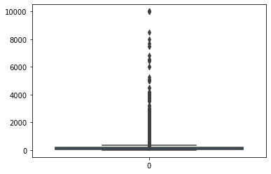

```python
sns.boxplot(data=df["price"])
```

```python
def remove_outlier_IQR(df):
    Q1=df.quantile(0.25)
    Q3=df.quantile(0.75)
    IQR=Q3-Q1
    df_final=df[~((df<(Q1-1.5*IQR)) | (df>(Q3+1.5*IQR)))]
    return df_final
```

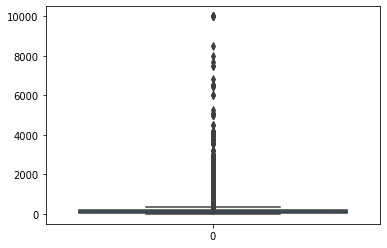

```python
sns.boxplot(data=df["price"])
```

```python
df["price"]=remove_outlier_IQR(df["price"])
df["price"].isnull().sum()
```

```
2972
```

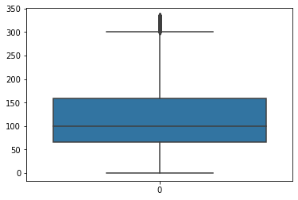

```python
sns.boxplot(data=df["price"])
```

```python
df=df.dropna(subset=['price'])
```

```python
len(df)
```

```
45923
```

```python
df.isnull().sum()
```

```
id                                   0
name                                15
host_id                              0
host_name                           21
neighbourhood_group                  0
neighbourhood                        0
latitude                             0
longitude                            0
room_type                            0
price                                0
minimum_nights                       0
number_of_reviews                    0
last_review                       9012
reviews_per_month                 9012
calculated_host_listings_count       0
availability_365                     0
dtype: int64
```

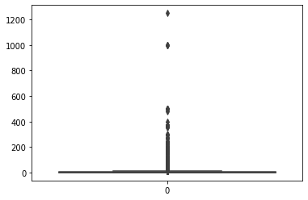

```python
sns.boxplot(data=df["minimum_nights"])
```

```python
df["minimum_nights"]=remove_outlier_IQR(df["minimum_nights"])
```

```python
df["minimum_nights"].isnull().sum()
```

```
6185
```

```python
df=df.dropna(subset=['minimum_nights'])
```

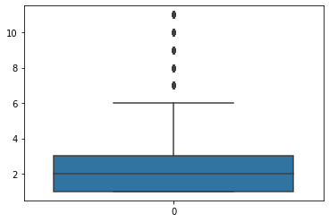

```python
sns.boxplot(data=df["minimum_nights"])
```

```python
len(df)
```

```
39738
```

```python
df.info()
```

```
<class 'pandas.core.frame.DataFrame'>
Int64Index: 39738 entries, 0 to 48894
Data columns (total 16 columns):
 #   Column                          Non-Null Count  Dtype
---  ------                          --------------  -----
 0   id                              39738 non-null  int64
 1   name                            39723 non-null  object
 2   host_id                         39738 non-null  int64
 3   host_name                       39718 non-null  object
 4   neighbourhood_group             39738 non-null  object
 5   neighbourhood                   39738 non-null  object
 6   latitude                        39738 non-null  float64
 7   longitude                       39738 non-null  float64
 8   room_type                       39738 non-null  object
 9   price                           39738 non-null  float64
 10  minimum_nights                  39738 non-null  float64
 11  number_of_reviews               39738 non-null  int64
 12  last_review                     33037 non-null  object
 13  reviews_per_month               33037 non-null  float64
 14  calculated_host_listings_count  39738 non-null  int64
 15  availability_365                39738 non-null  int64
dtypes: float64(5), int64(5), object(6)
memory usage: 6.2+ MB
```

## Distribution of Price

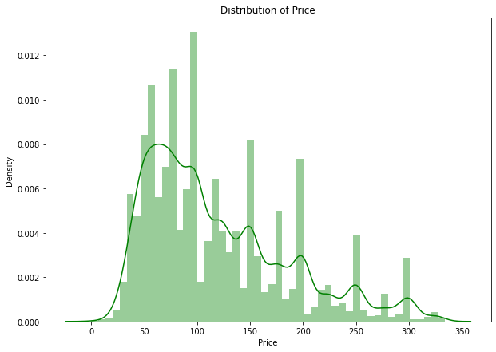

```python
plt.figure(figsize=(10,7))
sns.distplot(df.price,color='g')
plt.xlabel("Price")
plt.title("Distribution of Price")
plt.show()
```

```python
df["minimum_nights"].value_counts()
```

```
1.0     12067
2.0     11080
3.0      7375
4.0      3066
5.0      2821
7.0      1951
6.0       679
10.0      462
8.0       127
9.0        79
11.0       31
Name: minimum_nights, dtype: int64
```

### بیشتر تقاضا ها برای یک یا دو شب اقامت هست

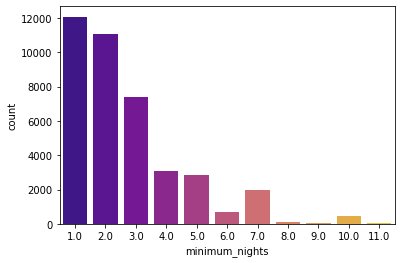

```python
#بیشتر تقاضا ها برای یک یا دو شب اقامت هست
sns.countplot(df["minimum_nights"], palette="plasma")
```

```python
df["room_type"].value_counts()
```

```
Private room       19866
Entire home/apt    18882
Shared room          990
Name: room_type, dtype: int64
```

### تقاضا کمی برای اتاق مشترک وجود دارد

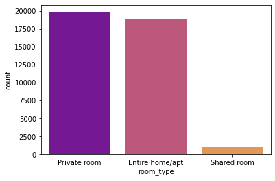

```python
#تقاضا کمی برای اتاق مشترک وجود دارد
sns.countplot(df["room_type"], palette="plasma")
```

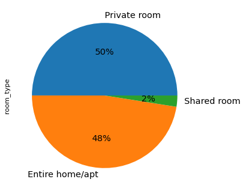

```python
fig = plt.figure(figsize=(5,5), dpi=80)
df['room_type'].value_counts().plot(kind='pie',  autopct='%1.0f%%', startangle=360, fontsize=13)
```

### گرانترین اتاق که در منهتن است و تعداد ریویو ها 14 است و قیمت آن 334 دلار

```python
#گرانترین اتاق که در منهتن است و تعداد ریویو ها 14 است و قیمت آن 334 دلار
df[df['price'] == df['price'].max()]
```

|  | id | name | host_id | host_name | neighbourhood_group | neighbourhood | latitude | longitude | room_type | price | minimum_nights | number_of_reviews | last_review | reviews_per_month | calculated_host_listings_count | availability_365 |
| --- | --- | --- | --- | --- | --- | --- | --- | --- | --- | --- | --- | --- | --- | --- | --- | --- |
| 2158 | 995367 | 1BR Apt as featured in New York Mag | 412783 | Nick | Manhattan | Greenwich Village | 40.73506 | -73.99728 | Entire home/apt | 334.0 | 11.0 | 14 | 2018-05-29 | 0.24 | 1 | 238 |

```python
df['number_of_reviews'].value_counts()
```

```
0      6701
1      4047
2      2794
3      2033
4      1631
       ...
313       1
540       1
363       1
326       1
341       1
Name: number_of_reviews, Length: 391, dtype: int64
```

### بیشترین ریویو

```python
#بیشترین ریویو
df[df['number_of_reviews'] == df['number_of_reviews'].max()]
```

|  | id | name | host_id | host_name | neighbourhood_group | neighbourhood | latitude | longitude | room_type | price | minimum_nights | number_of_reviews | last_review | reviews_per_month | calculated_host_listings_count | availability_365 |
| --- | --- | --- | --- | --- | --- | --- | --- | --- | --- | --- | --- | --- | --- | --- | --- | --- |
| 11759 | 9145202 | Room near JFK Queen Bed | 47621202 | Dona | Queens | Jamaica | 40.6673 | -73.76831 | Private room | 47.0 | 1.0 | 629 | 2019-07-05 | 14.58 | 2 | 333 |

### بیشترین reviews_per_month

```python
#بیشترین reviews_per_month
df[df['reviews_per_month'] == df['reviews_per_month'].max()]
```

|  | id | name | host_id | host_name | neighbourhood_group | neighbourhood | latitude | longitude | room_type | price | minimum_nights | number_of_reviews | last_review | reviews_per_month | calculated_host_listings_count | availability_365 |
| --- | --- | --- | --- | --- | --- | --- | --- | --- | --- | --- | --- | --- | --- | --- | --- | --- |
| 42075 | 32678719 | Enjoy great views of the City in our Deluxe Room! | 244361589 | Row NYC | Manhattan | Theater District | 40.75918 | -73.98801 | Private room | 100.0 | 1.0 | 156 | 2019-07-07 | 58.5 | 9 | 299 |

### برای اینکه شناسایی کنیم کدام ایدی ها بیشترین آکهی را لیست کردند

```python
#برای اینکه شناسایی کنیم کدام ایدی ها بیشترین آکهی را لیست کردند
top_host_list=df["host_id"].value_counts().head(10)
top_host_list
```

```
219517861    144
190921808     38
119669058     34
213781715     31
224414117     29
417504        23
252604696     20
134184451     18
201015598     17
177174475     17
Name: host_id, dtype: int64
```

```python
top_host_list_df=pd.DataFrame(top_host_list)
top_host_list_df.reset_index(inplace=True)
top_host_list_df.rename(columns={'index':'Host_ID', 'host_id':'P_Count'}, inplace=True)
top_host_list_df
```

|  | Host_ID | P_Count |
| --- | --- | --- |
| 0 | 219517861 | 144 |
| 1 | 190921808 | 38 |
| 2 | 119669058 | 34 |
| 3 | 213781715 | 31 |
| 4 | 224414117 | 29 |
| 5 | 417504 | 23 |
| 6 | 252604696 | 20 |
| 7 | 134184451 | 18 |
| 8 | 201015598 | 17 |
| 9 | 177174475 | 17 |

[output not shown]

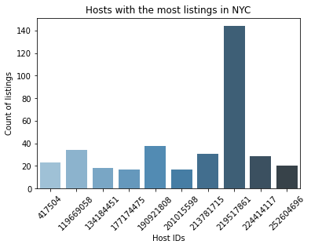

```python
most_list=sns.barplot(x="Host_ID", y="P_Count", data=top_host_list_df,
                 palette='Blues_d')
most_list.set_title('Hosts with the most listings in NYC')
most_list.set_ylabel('Count of listings')
most_list.set_xlabel('Host IDs')
most_list.set_xticklabels(most_list.get_xticklabels(), rotation=45)
```

```python
df["neighbourhood_group"].value_counts()
```

```
Brooklyn         17348
Manhattan        16009
Queens            5027
Bronx             1010
Staten Island      344
Name: neighbourhood_group, dtype: int64
```

### بیشتر اتاق ها در بروکلین و منهتن هستند

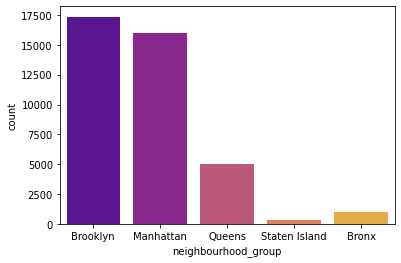

```python
#بیشتر اتاق ها در بروکلین و منهتن هستند
sns.countplot(df['neighbourhood_group'], palette="plasma")
```

### نقشه neighbourhood_group

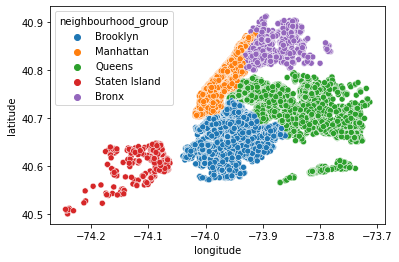

```python
#نقشه neighbourhood_group
sns.scatterplot(df.longitude,df.latitude,hue=df.neighbourhood_group)
```

### پراکندگی انواع اتاق در محله های شهر نیویورک

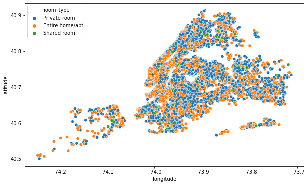

```python
#پراکندگی انواع اتاق در محله های شهر نیویورک
# همانطور که مشاهده میشود تعداد اتاق های اشتراکی آبی رنگ کم است
plt.figure(figsize=(10, 6))
sns.scatterplot(df.longitude,df.latitude,hue=df.room_type)
plt.ioff()
```

```python
neighbourhood_group = data.neighbourhood_group.unique()
neighborhoods_for_each_group = {}
for ngh_group in neighbourhood_group:
    neighborhoods_for_each_group[ngh_group] = {}
    neighborhoods_for_each_group[ngh_group]["places"] = data[data.neighbourhood_group == ngh_group].neighbourhood.unique()
    print(ngh_group, ' -> ', neighborhoods_for_each_group[ngh_group]['places'].size)
```

```
Brooklyn  ->  47
Manhattan  ->  32
Queens  ->  51
Staten Island  ->  43
Bronx  ->  48
```

```python
data[data.neighbourhood_group == "Bronx"].number_of_reviews.sum()
for ngh_group in neighborhoods_for_each_group:
    neighborhoods_for_each_group[ngh_group]["number_of_reviews"] = data[data.neighbourhood_group == ngh_group].number_of_reviews.sum()
# sns.barplot(y="neighbourhood_group", x="number_of_reviews", data=data)
```

```python
viz = []
for ngh in neighborhoods_for_each_group:
    viz.append([ngh, neighborhoods_for_each_group[ngh]['number_of_reviews']])
test = pd.DataFrame(viz, columns=['group', 'total_review'])
```

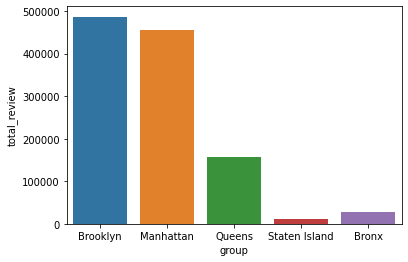

```python
sns.barplot(x= 'group', y='total_review', data=test)
```

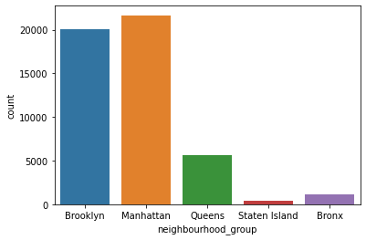

```python
sns.countplot(x="neighbourhood_group", data=data)
```

نمودار اول نمودار مربوط به مجموع کامنت ها در هر محله میباشد و در نمودار دوم تعداد کل میزبان ها رو در ۵ محله مختلف نشان دادیم همان طور که نمودار ها نشان میدهند تعداد کل کامنت ها یا ریو ها در بروکلین بیشتر از منهتن است اما در نمودار دوم تعداد میزبان ها در منهتن بیشتر از بروکلین هست با توجه به نقشه شهر نیویورک که در بالاتر دیدیم فکر میکردیم که محله کویین باید تعداد بیشتری میزبان داشته باشه نسبت به محله منهتن ولی نمودار دوم این فرض را رد میکنه پس نتیجه ای که میشه گرفت اینست که محله کویین بزرگتر از محله منهتن هست و میزبان ها در محله کویین پراکنده تر هستند ولی در محله منهتن که کوچک تر میباشد ولی تراکم میزبان ها خیلی بیتشر هست و در کل تعداد میزبان ها در منهتن بیشتر از بقیه محله ها من جمله کویین میباشد

.

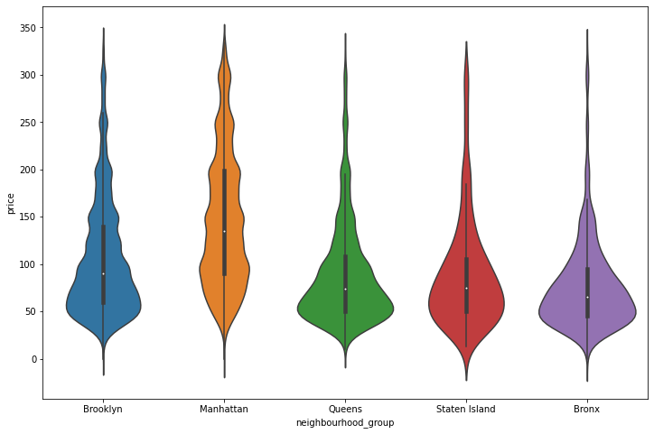

```python
plt.figure(figsize=(12, 8))
sns.violinplot(x='neighbourhood_group', y='price', data=data[data['price'] < 1000])
```

### ANOVA TEST for mean of price in neighbourhood_group (1)

```python
brooklyn_price = df[df['neighbourhood_group'] == 'Brooklyn'].price.values
manhatan_price = df[df['neighbourhood_group'] == 'Manhattan'].price.values
queens_price = df[df['neighbourhood_group'] == 'Queens'].price.values
staten_island_price = df[df['neighbourhood_group'] == 'Staten Island'].price.values
bronx_price = df[df['neighbourhood_group'] == 'Bronx'].price.values
```

```python
stats.f_oneway(bronx_price, manhatan_price, queens_price, staten_island_price, brooklyn_price)
```

```
F_onewayResult(statistic=1130.5083776808533, pvalue=0.0)
```

because p-value is too small alternative hypothesis is true. it means that price mean in neighbourhood_group are diffrent

فرض 0 این است که میانگین قیمت ها در محله ها یکسان هست

فرض 1 اینست که میانگین قیمت ها در محله ها با هم متفاوت است

در نهایت با توجه به مقدار پی ولیو فرض 0 رد و فرض 1 پذیرفته میشود

### Chi Squared Test (2)

H0 (null hypothesis): There is no association between Room Type and Neighbourhood Group.

H1 (alternate hypothesis): There is an association between Room Type and Neighbourhood Group.

```python
tab = pd.crosstab(df['room_type'],df['neighbourhood_group'])
```

```python
st.chi2_contingency(tab)
```

```
(636.9400606717613,
 2.6630240238114485e-132,
 8,
 array([[4.79913936e+02, 8.24311581e+03, 7.60687347e+03, 2.38864095e+03,
         1.63455836e+02],
        [5.04923751e+02, 8.67269032e+03, 8.00329141e+03, 2.51312049e+03,
         1.71974030e+02],
        [2.51623132e+01, 4.32193870e+02, 3.98835120e+02, 1.25238563e+02,
         8.57013438e+00]]))
```

با توجه به مقدار پی ولیو فرض 1 پذیرفته میشود یعنی میان نوع اتاق و محله ارتباط وجود دارد مثلا تعداد اتاق های خصوصی در

```python
Brooklyn_night = data[data.neighbourhood_group == 'Brooklyn'].minimum_nights.values
Monhatan_night = data[data.neighbourhood_group == 'Manhattan'].minimum_nights.values
Queens_night = data[data.neighbourhood_group == 'Queens'].minimum_nights.values
Stateen_Island_night = data[data.neighbourhood_group == 'Staten Island'].minimum_nights.values
Bronx_night = data[data.neighbourhood_group == 'Bronx'].minimum_nights.values
```

```python
print("mean")
print("Brooklyn_night : ", Brooklyn_night.mean())
print("Monhatan_night : ", Monhatan_night.mean())
print("Queens_night : ", Queens_night.mean())
print("Stateen_Island_night : ", Stateen_Island_night.mean())
print("Bronx_night : ", Bronx_night.mean())
```

```
mean
Brooklyn_night :  6.056555909271787
Monhatan_night :  8.579151470384563
Queens_night :  5.181433109777621
Stateen_Island_night :  4.831099195710456
Bronx_night :  4.560953253895509
```

مانند دفعه قبل که دنبال ارتباطی بین حداقل شب اجاره و قیمت بودیم این دفعه دنبال ارتباط بین حداقل شب اجاره و لوکیشن هستیم که بینم ایا در محله های مختلف حداقل شب اجاره ها فرق دارند یا نه برای این کار دوبار از تست آنووا کمک میگیریم قبل از این که تست رو اجرا کنیم میانگین حداقل شب اجاره برای محله های مختلف رو پیدا کردیم .... همون طور که مشاهده میشه میانگین حداقل شب اجاره در لوکیشن های مختلف متفاوت عه و نکته جالب اینست که منهتن که میانگین قیمتی بالاتری نسبت به همه لوکیشن ها داره در این جا هم میانگین حداقل شب اجاره ش هم از همه بالاتر هست

### ANOVA for mean of minimum_nights in each neighbourhood_group (3)

```python
stats.f_oneway(Brooklyn_night, Monhatan_night, Queens_night, Stateen_Island_night, Bronx_night)
```

```
F_onewayResult(statistic=59.022846173576504, pvalue=8.519876027562454e-50)
```

خب همین طور که میبینیم مقدار پی ولیو از مقدار آلفا کوچک تره پس فرض صفر که برابر بودن میانگین حداقل شب اجاره برای هر محله ای هست رد میشود

```python
#چونکه دو ویژگی زیر مقادیر پوچ زیادی داشتند آنها را حذف میکنیم
df=df.drop(["last_review"],axis=1)
```

```python
df=df.drop(["name","id","host_id","host_name","latitude","longitude"],axis=1)
```

```python
df=df.drop(["neighbourhood"],axis=1)
```

```python
df=df.drop(["number_of_reviews","reviews_per_month"],axis=1)
```

```python
df.info()
```

```
<class 'pandas.core.frame.DataFrame'>
Int64Index: 39738 entries, 0 to 48894
Data columns (total 6 columns):
 #   Column                          Non-Null Count  Dtype
---  ------                          --------------  -----
 0   neighbourhood_group             39738 non-null  object
 1   room_type                       39738 non-null  object
 2   price                           39738 non-null  float64
 3   minimum_nights                  39738 non-null  float64
 4   calculated_host_listings_count  39738 non-null  int64
 5   availability_365                39738 non-null  int64
dtypes: float64(2), int64(2), object(2)
memory usage: 3.1+ MB
```

```python
df.corr()
```

|  | price | minimum_nights | calculated_host_listings_count | availability_365 |
| --- | --- | --- | --- | --- |
| price | 1.000000 | 0.059901 | 0.088708 | 0.027122 |
| minimum_nights | 0.059901 | 1.000000 | -0.031173 | -0.097462 |
| calculated_host_listings_count | 0.088708 | -0.031173 | 1.000000 | 0.129584 |
| availability_365 | 0.027122 | -0.097462 | 0.129584 | 1.000000 |

### one hot encoding

```python
one_hot_encoded_data = pd.get_dummies(df, columns = ['neighbourhood_group', 'room_type'])
```

```python
one_hot_encoded_data
```

|  | price | minimum_nights | calculated_host_listings_count | availability_365 | neighbourhood_group_Bronx | neighbourhood_group_Brooklyn | neighbourhood_group_Manhattan | neighbourhood_group_Queens | neighbourhood_group_Staten Island | room_type_Entire home/apt | room_type_Private room | room_type_Shared room |
| --- | --- | --- | --- | --- | --- | --- | --- | --- | --- | --- | --- | --- |
| 0 | 149.0 | 1.0 | 6 | 365 | 0 | 1 | 0 | 0 | 0 | 0 | 1 | 0 |
| 1 | 225.0 | 1.0 | 2 | 355 | 0 | 0 | 1 | 0 | 0 | 1 | 0 | 0 |
| 2 | 150.0 | 3.0 | 1 | 365 | 0 | 0 | 1 | 0 | 0 | 0 | 1 | 0 |
| 3 | 89.0 | 1.0 | 1 | 194 | 0 | 1 | 0 | 0 | 0 | 1 | 0 | 0 |
| 4 | 80.0 | 10.0 | 1 | 0 | 0 | 0 | 1 | 0 | 0 | 1 | 0 | 0 |
| ... | ... | ... | ... | ... | ... | ... | ... | ... | ... | ... | ... | ... |
| 48890 | 70.0 | 2.0 | 2 | 9 | 0 | 1 | 0 | 0 | 0 | 0 | 1 | 0 |
| 48891 | 40.0 | 4.0 | 2 | 36 | 0 | 1 | 0 | 0 | 0 | 0 | 1 | 0 |
| 48892 | 115.0 | 10.0 | 1 | 27 | 0 | 0 | 1 | 0 | 0 | 1 | 0 | 0 |
| 48893 | 55.0 | 1.0 | 6 | 2 | 0 | 0 | 1 | 0 | 0 | 0 | 0 | 1 |
| 48894 | 90.0 | 7.0 | 1 | 23 | 0 | 0 | 1 | 0 | 0 | 0 | 1 | 0 |

39738 rows × 12 columns

```python
one_hot_encoded_data.isnull().sum()
```

```
price                                0
minimum_nights                       0
calculated_host_listings_count       0
availability_365                     0
neighbourhood_group_Bronx            0
neighbourhood_group_Brooklyn         0
neighbourhood_group_Manhattan        0
neighbourhood_group_Queens           0
neighbourhood_group_Staten Island    0
room_type_Entire home/apt            0
room_type_Private room               0
room_type_Shared room                0
dtype: int64
```

### normalization mean=0, std=1

```python
mean1=one_hot_encoded_data.mean()
std1=one_hot_encoded_data.std()
```

```python
diff1=one_hot_encoded_data-mean1
```

```python
normalized=diff1/std1
```

```python
normalized.describe()
```

|  | price | minimum_nights | calculated_host_listings_count | availability_365 | neighbourhood_group_Bronx | neighbourhood_group_Brooklyn | neighbourhood_group_Manhattan | neighbourhood_group_Queens | neighbourhood_group_Staten Island | room_type_Entire home/apt | room_type_Private room | room_type_Shared room |
| --- | --- | --- | --- | --- | --- | --- | --- | --- | --- | --- | --- | --- |
| count | 3.973800e+04 | 3.973800e+04 | 39738.000000 | 3.973800e+04 | 3.973800e+04 | 3.973800e+04 | 3.973800e+04 | 3.973800e+04 | 3.973800e+04 | 3.973800e+04 | 3.973800e+04 | 3.973800e+04 |
| mean | -3.576137e-17 | 1.287409e-16 | 0.000000 | 1.144364e-17 | -6.580093e-17 | -4.863547e-17 | -2.297668e-17 | 3.433092e-17 | -2.574819e-17 | -3.576137e-17 | 5.578774e-17 | -2.288728e-17 |
| std | 1.000000e+00 | 1.000000e+00 | 1.000000 | 1.000000e+00 | 1.000000e+00 | 1.000000e+00 | 1.000000e+00 | 1.000000e+00 | 1.000000e+00 | 1.000000e+00 | 1.000000e+00 | 1.000000e+00 |
| min | -1.771267e+00 | -9.101832e-01 | -0.104997 | -7.813196e-01 | -1.614889e-01 | -8.802220e-01 | -8.213664e-01 | -3.805532e-01 | -9.344557e-02 | -9.514874e-01 | -9.998364e-01 | -1.598407e-01 |
| 25% | -8.037784e-01 | -9.101832e-01 | -0.104997 | -7.813196e-01 | -1.614889e-01 | -8.802220e-01 | -8.213664e-01 | -3.805532e-01 | -9.344557e-02 | -9.514874e-01 | -9.998364e-01 | -1.598407e-01 |
| 50% | -2.828230e-01 | -3.735691e-01 | -0.104997 | -5.803005e-01 | -1.614889e-01 | -8.802220e-01 | -8.213664e-01 | -3.805532e-01 | -9.344557e-02 | -9.514874e-01 | -9.998364e-01 | -1.598407e-01 |
| 75% | 5.320999e-01 | 1.630449e-01 | -0.054349 | 6.579769e-01 | -1.614889e-01 | 1.136049e+00 | 1.217453e+00 | -3.805532e-01 | -9.344557e-02 | 1.050960e+00 | 1.000138e+00 | -1.598407e-01 |
| max | 3.200135e+00 | 4.455957e+00 | 16.406461 | 2.153559e+00 | 6.192220e+00 | 1.136049e+00 | 1.217453e+00 | 2.627687e+00 | 1.070115e+01 | 1.050960e+00 | 1.000138e+00 | 6.256070e+00 |

```python
y=normalized["price"]
```

```python
x=normalized.drop(["price"],axis=1)
```

```python
x.shape
```

```
(39738, 11)
```

#### split data to train and test

```python
from sklearn.model_selection import train_test_split
X_train, X_test, y_train, y_test = train_test_split( x, y, test_size=0.33, random_state=42)
```

```python
def reg_report(true, pred, name='Test'):
    print("\n{} Results :\n".format(name))
    print("RSS is :",sum((pred-true)**2))
    print("RSE is :",math.sqrt(sum((pred-true)**2)*(1/(len(pred)-2))))
    print("TSS is :",sum((true-true.mean())**2))
    print("R Squared is :",1-(sum((pred-true)**2)/sum((true-true.mean())**2)))
    print("MSE is :",((pred-true)**2).mean())
    print('MAE is :',(abs(pred-true)).mean())



def eval_report(y_train, pred_train,y_test, pred_test):
    reg_report(y_train, pred_train, name='Train')
    reg_report(y_test, pred_test, name='Test')
```

```python
reg = LinearRegression()
reg.fit(X_train, y_train)
test_pred = reg.predict(X_test)
train_pred = reg.predict(X_train)
eval_report(y_train, train_pred, y_test, test_pred)
```

```
Train Results :

RSS is : 14625.585497051492
RSE is : 0.7412015023472315
TSS is : 26642.991757255073
R Squared is : 0.4510531838801908
MSE is : 0.549338397575553
MAE is : 0.5497333764315231

Test Results :

RSS is : 7045.922406138519
RSE is : 0.7330514511262916
TSS is : 13093.854967292094
R Squared is : 0.46189090808330013
MSE is : 0.5372824772105019
MAE is : 0.5392610261745753
```

```python
pvt = df[df['room_type'] == 'Private room']
share = df[df['room_type'] == 'Shared room']
apt = df[df['room_type'] == 'Entire home/apt']
```

### Levene Test (for testing of variance) (4)

H0 (null hypothesis): variance(private_room) = variance(shared_room) = variance(entire_home)

H1 (alternate hypothesis): variance(private_room) != variance(shared_room) != variance(entire_home)

```python
st.levene(pvt.price, share.price, apt.price)
```

```
LeveneResult(statistic=1912.475123766809, pvalue=0.0)
```

با توجه به مقدار کم و نزدیک به صفر پی ولیو فرض 0 رد میشود و فرض 1 پذیرفته میشود که میگوید واریانس ها یکسان نیست

### Kruskal Wallis Test (5)

H0 (null hypothesis): mean_price(private_room) = mean_price(shared_room) = mean_price(entire_home/apt)

H1 (alternate hypothesis): mean_price(private_room) != mean_price(shared_room) != mean_price(entire_home/apt)

```python
st.kruskal(pvt.price,share.price,apt.price)
```

```
KruskalResult(statistic=17737.15768469572, pvalue=0.0)
```

با توجه به مقدار پی ولیو فرض 0 رد میشود و فرض 1 پذیرفته میشود یعنی میانگین قیمت انواع اتاق ها با هم یکسان نیست و متفاوت میباشد

### One Way ANOVA (6)

H0 (null hypothesis): mean_price(private_room) = mean_price(shared_room) = mean_price(entire_home/apt)

H1 (alternate hypothesis): mean_price(private_room) != mean_price(shared_room) != mean_price(entire_home/apt)

```python
st.f_oneway(pvt.price,share.price,apt.price)
```

```
F_onewayResult(statistic=11940.179600330222, pvalue=0.0)
```

با توجه به مقدار پی ولیو فرض 0 رد میشود و فرض 1 پذیرفته میشود یعنی میانگین قیمت انواع اتاق ها با هم یکسان نیست و متفاوت میباشد